# Where Patrick Should Be

Scheduling Your Shop Visits Using 250 Days of Productivity Data

Author

Analytics Brief for Patrick’s Auto Shop Network

Published

May 13, 2026

## Executive summary

Patrick, you asked one practical question: **when you walk through the door, where does your presence pay off the most?** From 250 daily records (50 days × 5 shops), on days you stood with the crew, shops averaged more cars fixed than on days you were elsewhere—but **not by the same amount at every location**.

**Bottom line:**

- **Biggest productivity lift when you’re on site:** Shop 4, then Shop 2, then Shop 5, then Shop 1. **Smallest lift:** Shop 3 (where your brother works).
- **Shop 3 is the only location where we cannot rule out “no real lift”** from this history alone—the improvement there is small and could partly be random noise.
- **Money picture (illustrative):** If we assume about **$450 revenue per car** and about **220 visit-days per year**, shifting how you spread those days can change expected extra cars—and revenue—by a meaningful amount (see scenarios later). The exact dollars depend on your real ticket average; the *rankings* of shops still hold.

## What the data shows

Your spreadsheet tracks **one row per shop per day**: 50 calendar days across the whole network, five shops each day. On each day you were at exactly one shop (`boss = 1` on that shop’s row). That gives **250 points** on the chart below—every single day in the file.

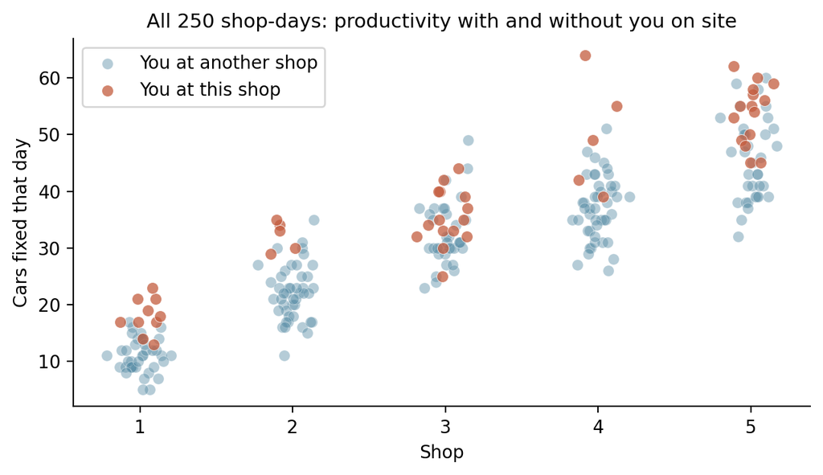

Figure 1: Each dot is one shop-day: cars fixed that day, by shop. Jitter spreads overlapping dots. Orange = you were there; blue = you were at another shop that day.

### Lift when you’re there

For each shop, we compared **average cars on days you were there** vs **average cars on days you were not** (because you were at a different shop that day). The gap is the **lift** from your presence.

Table 1: Average daily lift (extra cars) when you are at that shop vs. when you are not. Sample sizes are the number of shop-days in each column.

|  | Shop | Lift (cars/day) | Approx. 95% range for lift | Days without you (n) | Days with you (n) | Typical p-value (two-sample t-test) |
| --- | --- | --- | --- | --- | --- | --- |
| 0 | 1 | 6.95 | 4.9 to 9.0 | 40 | 10 | 0.000 |
| 1 | 2 | 10.07 | 7.6 to 12.5 | 45 | 5 | 0.000 |
| 2 | 3 | 2.94 | -0.1 to 6.0 | 35 | 15 | 0.076 |
| 3 | 4 | 12.78 | 5.0 to 21.0 | 45 | 5 | 0.046 |
| 4 | 5 | 8.22 | 4.7 to 11.7 | 35 | 15 | 0.000 |

**Read this like a mechanic:** A higher lift means **each visit tends to pull more work through the door** at that location. Shop 4 shows the largest gap; Shop 3 shows the smallest.

## What you should do

1. **Protect high-lift days for Shops 4 and 2.** Those locations move the needle the most per visit. When you have slow seasons or staffing crunch, **anchor your calendar there first**.
2. **Treat Shop 5 and Shop 1 as “solid seconds”—not optional forever.** They still show clear lifts; skipping them for months leaves money on the table.
3. **Shop 3 (your brother’s):** The data does **not** prove a strong boost. Enjoy family time—but **do not schedule Shop 3 instead of Shop 4 or 2 for revenue reasons.** Visiting your brother is a **personal** bonus; the numbers say it is **not** where you buy the most throughput.

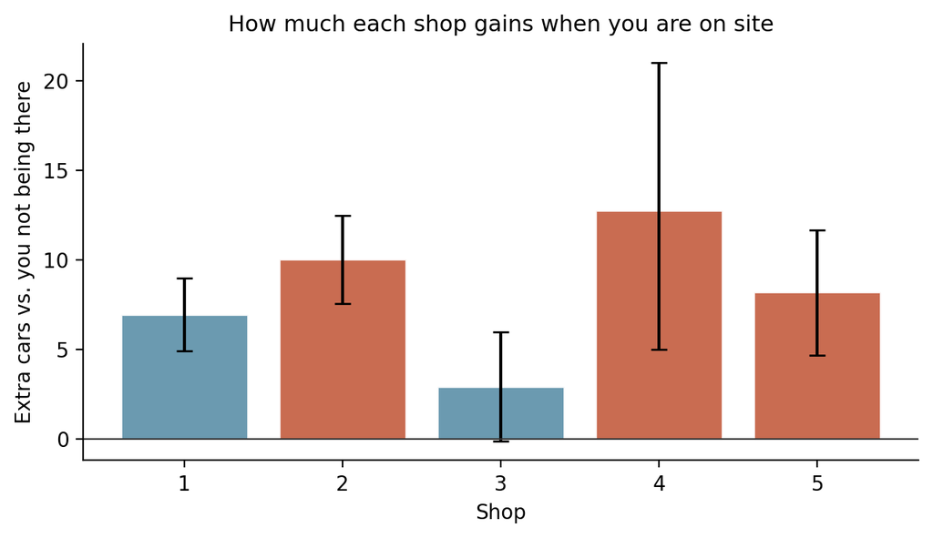

Figure 2: Estimated extra cars per day when you work at that shop, compared with days you are elsewhere. Error bars show approximate 95% bootstrap ranges (see confidence section).

## Money: rough revenue impact

We do not know your exact average ticket. The table uses **$450 per car** only to turn cars into dollars so you can feel the scale—**swap your real number** into the same math.

Table 2: Illustrative annual lift from your visits under three scheduling styles. “Extra cars” is only the portion tied to where you choose to be—assuming lifts stay similar to history.

|  | Scenario | Extra cars / year (approx.) | Extra revenue / year (@ $450/car) |
| --- | --- | --- | --- |
| 0 | Even split (20% each shop) | 1802.0 | 810936.0 |
| 1 | Revenue-focused (weight on Shops 4, 2, and 5) | 2075.0 | 933562.0 |
| 2 | Family-first (half of visit-days at Shop 3) | 1391.0 | 625939.0 |

**How to read it:** These scenarios **do not** predict total shop revenue; they approximate **extra cars tied to your routing decision**, holding everything else flat. The gap between “even split” and “revenue-focused” is the kind of swing you could see if you **shift days** toward higher-lift shops and away from Shop 3.

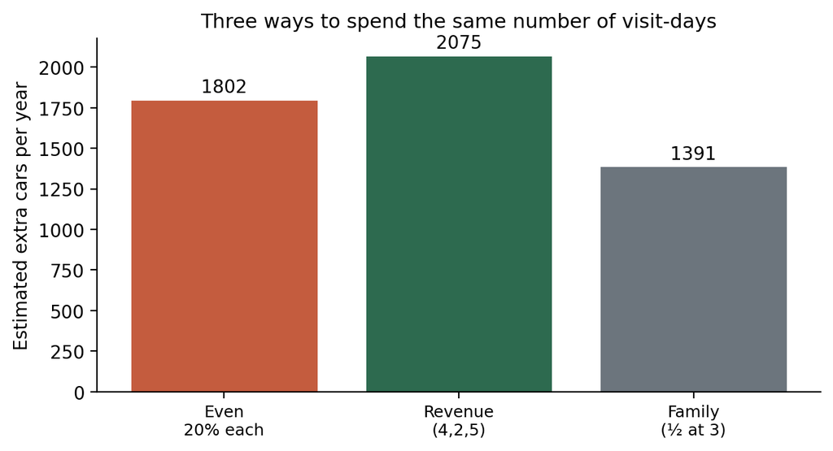

Figure 3: Projected extra cars per year from your visits under three example schedules (220 visit days, lifts from the historical data).

## How confident can you be?

**Honest answer:** 250 shop-days is enough to see **big, repeated patterns**, but it is **not** a decade of data. Think of it like evaluating a part based on a few months of wear—not useless, not perfect.

- **Ranges, not guarantees:** The “approx. 95% range” column is a plain-language band for how far the true lift could move if we repeated similar months. **Wide bands (Shop 4)** mean **fewer days in the data with you there**, so luck swings more.
- **Shop 3:** The lift is small and the statistical check lines up with **“might be partly noise.”** That does **not** mean family visits are wrong—it means **profit-based scheduling should not favor Shop 3**.
- **What could go wrong:** Future staffing, marketing, or neighborhood traffic could change faster than this history. **Assumption:** past lifts **roughly** carry forward if operations stay similar.

## Closing

Use your presence where the **lift per visit** is clearest: **Shop 4 and Shop 2 first**, **Shop 5 and Shop 1 next**, and treat **Shop 3** as **family time**, not your revenue engine. Revisit the numbers after another season of tracking—you’ll shrink the uncertainty bands and sharpen the schedule again.